# Data Types

Sasha Bakker

8/31/2020

## Part I

### 1. The normal distribution

Explore the normal distribution in R by reading about related functions by `?rnorm`.

1. Generate $n=100$ random draws from the standard normal distribution and assign those to the variable `s`.

```r
set.seed(1) # keep the random numbers generated
s <- rnorm(100, mean=0, sd=1) # generate 100 quasi-random numbers
```

2. What are the type and dimensions of the data that the function takes as input here?

input: numeric vector of length 1 (scalar)

3. What are the type and dimensions of the data that the function returns?

numeric vector (double) of length n = 100

4. Use `hist()` to plot a histogram of `s`, normalized to be a density (so that the total area of the bars is 1, check `?hist)`, make sure that the number of `breaks` (a parameter in the `hist()` function) does justice to your data, as the default value is not good enough at times. Justify your choice (you can provide several figures, prior knowledge or any other convincing argument).

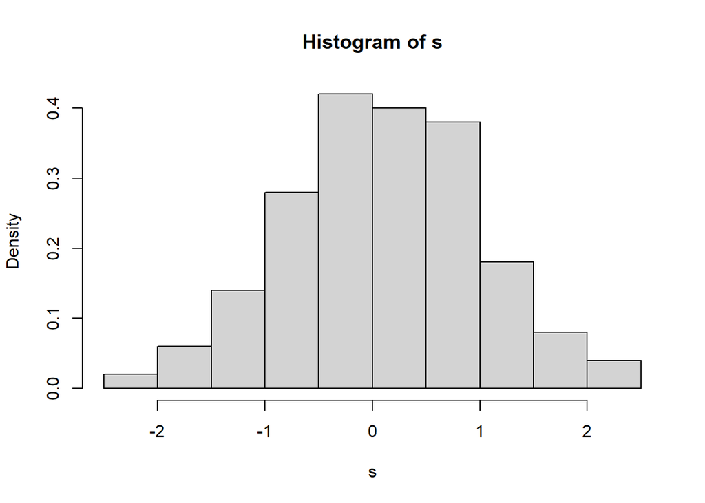

```r
hist(s, freq=FALSE) # plot normalized (density) histogram of `s`
```

The default setting for breaks is satisfactory because the histogram has the approximate appearance of a normal curve.

5. Add a line to the histogram that shows the theoretical normal density

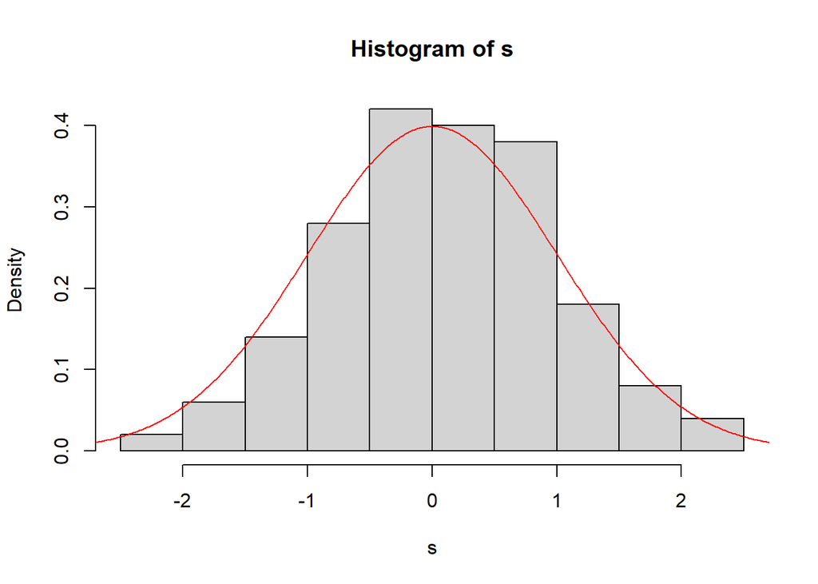

```r
hist(s, freq=FALSE)
xseq <- seq(-3,3,0.01) # lower-bound = -3, upper-bound = 3, increment = 0.01
dens <- dnorm(xseq) # create a normal curve with x-values = `xseq`
lines(xseq, dens, col="red")
```

`xseq` is a vector of doubles. `dnorm()` input is a vector of doubles and `dnorm()` output is a vector of doubles. This function operates element by element.

6. Plot another histogram of the standard normal CDF when applied to s (a transformation of a random variable is another random variable). Do you identify this distribution? Hint: start by identifying the range of values that are generated. If you are not sure, try taking a larger n.

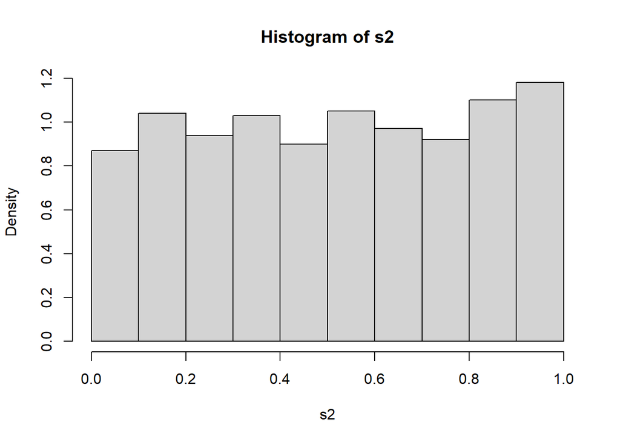

```r
set.seed(2) # keep the random numbers generated
s1 <- rnorm(1000, mean=0, sd=1) # generate 1000 quasi-random numbers
s2 <- pnorm(s1, mean=0, sd=1) # gives the CDF
hist(s2, freq=FALSE) # histogram of densities
```

The probability distribution of the random numbers pulled from a normal distribution is like a dice roll. For large enough N, the probability densities of getting each number become equal.

### 1. Sampling from the truncated normal distribution

The truncated normal distribution is the probability distribution derived from that of a normally distributed random variable by bounding the random variable from either below or above (or both) (see Wikipedia).

In this exercise we will generate samples from a truncated normal random variable in a very simple way.

Our goal is to sample from a truncated normal distribution that is derived from a standard normal variable that is truncated from below at 0.5.

1. First, generate `n=10000` samples from a standard normal variable, assign those to, say, a variable named `s`.

```r
set.seed(3) # keep the random numbers generated
s3 <- rnorm(1000, mean=0, sd=1) # generate 10000 quasi-random numbers
```

2. Then, using a single command, assign to a new variable, say, `trunc_s`, all the values of `s` that are greater than or equal 0.5. **Explain in words exactly each stage of the computation, which functions are used, what are their input and output data types, etc.**

```r
trunc_s <- s3[s3>=0.5] # truncate the the data
```

That is it! We generated a sample of truncated normal values.

3. Use `hist()` to plot a histogram of `trunc_s`, normalized to be a density, make sure that the number of `breaks` does justice to your data. Justify your choice.

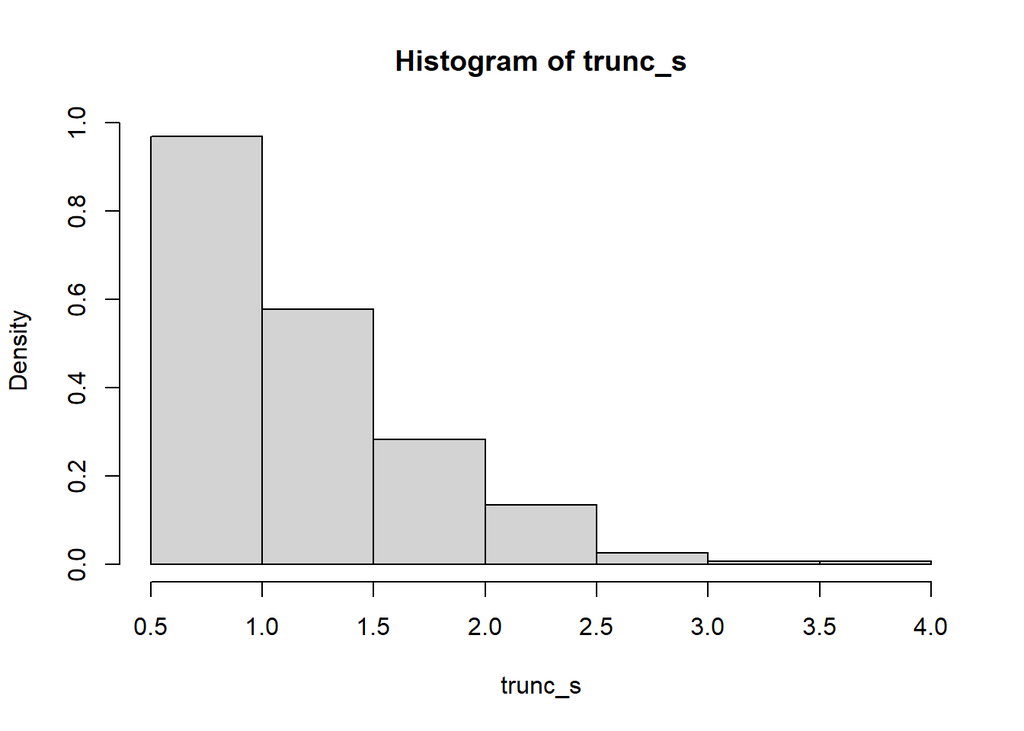

```r
hist(trunc_s, freq=FALSE)
```

The default setting for breaks is satisfactory because the samples were from a standard normal random variable with `mean = 0` and there is a lower bound of 0.5 such that we expect the histogram to have the greatest density at the left and to be decreasing in density toward the right.

4. Let us compare the results to the theoretical density. Choose a range for which you want to compute the density, and assign it to a vector. Using only basic operators and functions for the standard normal family (from `dnorm`, `pnorm`, `qnorm`, `rnorm`) and the formula for the density of the truncated normal random variable from Wikipedia that operate on the range vector or other constants (note, we are using `b=Inf` here, what are the other constants?) to compute the density of the truncated normal and add a red line to the histogram that depicts it. For legibility, you may separate the computations to, say, `numerator` and `denominator`. **Carefully describe each part of your computation: which functions operate on which data types? Is recycling used? Is the computation element by element?**

The probability density function for a truncated normal distribution over $a \leq x \leq b$ is given by

$$f(x;\mu,\sigma,a,b) = \frac{1}{\sigma} \frac{\phi(\frac{x-\mu}{\sigma})}{\Phi(\frac{b-\mu}{\sigma})-\Phi(\frac{a-\mu}{\sigma})}$$
where the probability density function of a standard normal distribution is

$$\phi(\xi) = \frac{1}{\sqrt{2\pi}} \text{exp}(-\frac{1}{2}\xi^2)$$

and its cumulative distribution function is

$$\Phi(x) = \frac{1}{2}(1 + \text{erf}(1/\sqrt{2})).$$
By definition, if $b=\infty$, then $\Phi(\frac{b-\mu}{\sigma}) = 1$.

Thus, for $a =0.5$ and $b=\infty$, our equation becomes:

$$f(x;\mu,\sigma,0.5,\infty) = \frac{1}{\sigma} \frac{\phi(\frac{x-\mu}{\sigma})}{1-\Phi(\frac{0.5-\mu}{\sigma})}$$

and, due to our initialization, we can further reduce it to:

$$f(x;0,1,0.5,\infty) = \frac{\phi(x)}{1-\Phi(0.5)}.$$
In R, the probability density function of the standard normal distribution is `dnorm()` and the cumulative distribution function is `pnorm()`.

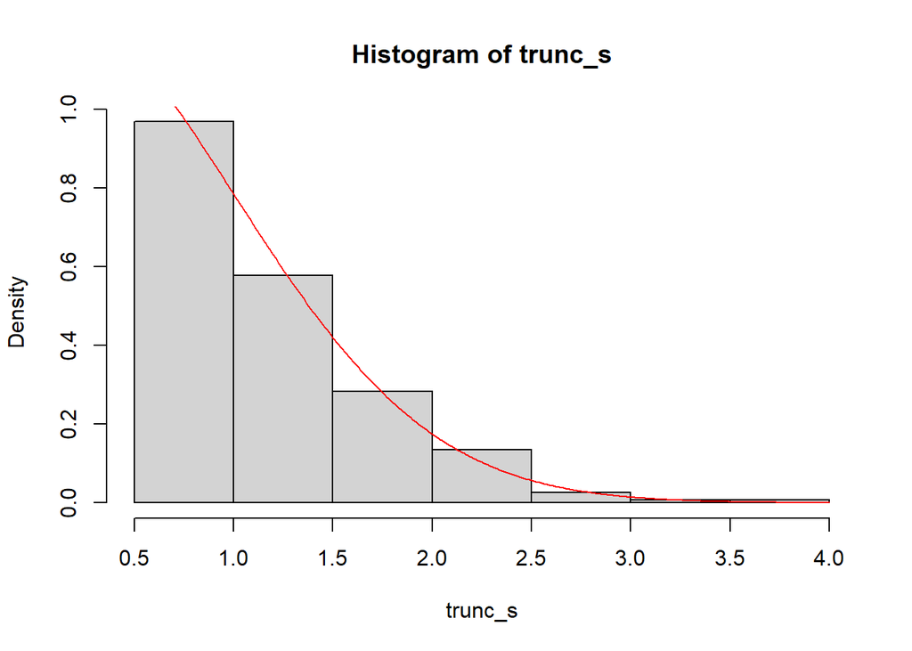

```r
xvals <- seq(0.5,4.0,0.01) #lower-bound = 0.5, upper-bound = 4, increment = 0.01
phi_x <- dnorm(xvals, mean=0, sd=1) # standard normal dist
Phi <- pnorm(0.5, mean=0, sd=1) # CDF evaluated at 0.5
f_x <- phi_x / (1-Phi)
hist(trunc_s, freq = FALSE)
lines(xvals, f_x, col="red")
```

We begin by defining a numerical vector of doubles with the range of our histogram called `xvals`. This was initialized by the function `seq()` which takes scalars as input.

We then use the numerical vector of doubles `xvals` as input in the standard normal function `dnorm()` which outputs another numerical vector of doubles. We also use the cumulative distribution function `pnorm()` with input as a scalar and output as a scalar (we can input a numeric vector of any length and it would output a numeric vector of the same length).

Finally, we compute the truncated normal distribution density which is a numeric vector evaluated for `xvals` and assign it to the variable name `f_x`. Recycling is used here because `Phi` is a scalar whereas `phi_x` has the length 351. Thus, the value of `Phi` is recycled to have the same length as `phi_x`. The computation uses element-wise division where elements of corresponding indices are divided by one another.

The results of the histogram match the theoretical density.

5. Using the same careful descriptions as in the above, compute the expected value and standard deviation for this truncated normal distribution (based on the theoretical formulas) as well as the average and empirical standard deviation of the sample. Absurdly as it may sound, if you do this correctly, something should go wrong for the theoretical standard deviation. What went wrong? Fix it in a new chunk of code! Are the final values near?

The expected value or the mean of the truncated normal distribution is

$$\mu + \frac{\phi(\alpha)-\phi(\beta)}{Z}\sigma$$

and the variance is

$$\sigma^2 \left[1 + \frac{\alpha\phi(\alpha)-\beta\phi(\beta)}{Z}- \left( \frac{\phi(\alpha)-\phi(\beta)}{Z} \right)^2 \right]$$

where $\alpha = \frac{a-\mu}{\sigma}$, $\beta = \frac{b-\mu}{\sigma}$, and $Z = \Phi(\beta) - \Phi(\alpha)$.

In this problem $\alpha = 0.5$, $\beta = \infty$, and $Z = 1 - \Phi(0.5)$.

```r
# initialize variables
mu <- 0
sig <- 1
alpha <- 0.5
beta <- Inf
Z <- 1 - Phi
phi_alpha <- dnorm(alpha, mean=0, sd=1) # input vector (scalar) into function dnorm() with vector output (scalar)
phi_beta <- dnorm(beta, mean=0, sd=1) # input vector (scalar) into function dnorm() with vector output (scalar)

# calculate the expected value
expected <- mu + (phi_alpha - phi_beta)/Z # use expected value equation for truncated normal dist
sprintf("The expected value is: %s", expected)
```

```
## [1] "The expected value is: 1.14107777036806"
```

```r
# calculate the standard deviation
frac1 <- (alpha * phi_alpha - beta * phi_beta) / Z
frac2 <- (phi_alpha - phi_beta) / Z
stdev <- sig * sqrt(1 + frac1 + frac2^2) # use the square root of the variance equation for truncated normal dist
sprintf("The theoretical standard deviation is: %s", stdev)
```

```
## [1] "The theoretical standard deviation is: NaN"
```

```r
# calculate the standard deviation
frac1 <- (alpha * phi_alpha) / Z # modified this part of the calculation
frac2 <- (phi_alpha - phi_beta) / Z
stdev <- sig * sqrt(1 + frac1 + frac2^2)
sprintf("The theoretical standard deviation is: %s", stdev)
```

```
## [1] "The theoretical standard deviation is: 1.69487384876049"
```

Now that we have computed the theoretical expectation and standard deviation, let us calculate the mean and standard deviation of the sample.

```r
sprintf("The sample mean is: %s", mean(trunc_s)) # input numeric vector into function mean() and output a scalar
```

```
## [1] "The sample mean is: 1.13941236550581"
```

```r
sprintf("The sample standard devaition is: %s", sd(trunc_s)) # input numeric vector into function sd() and output a scalar
```

```
## [1] "The sample standard devaition is: 0.527463837688908"
```

6. Let us compare the results to the truncnorm package. First, install the package and load it. Then, apply dtruncnorm (with the correct parameters) to the same range you used before. Add another, blue dashed line to the histogram and check whether or not the lines are similar.

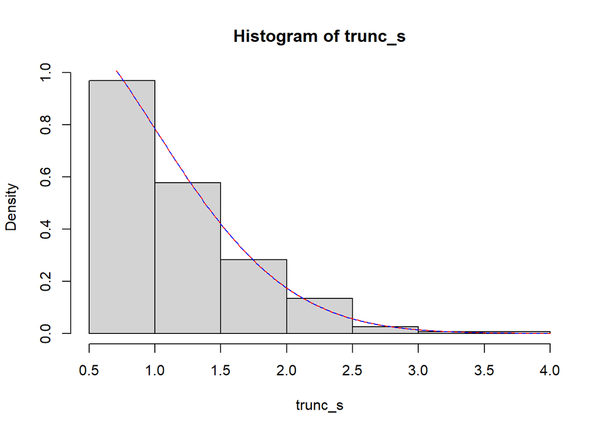

```r
library(truncnorm) # load the package
f_d <- dtruncnorm(xvals, a=0.5, b=Inf, mean=0, sd=1) # input numeric vector into function dtruncnorm() and output a numeric vector
hist(trunc_s, freq = FALSE) # plot histogram of values
lines(xvals, f_x, col="red") # red line to represent the theoretical distribution
lines(xvals, f_d, col="blue", lty=2) # dashed blue line to represent the distribution using the truncnorm package
```

The red line and the blue dashed line are overlapping.

7. Are the values you computed for the truncated normal density and the ones from the package “the same” (check in at least 3 ways)?

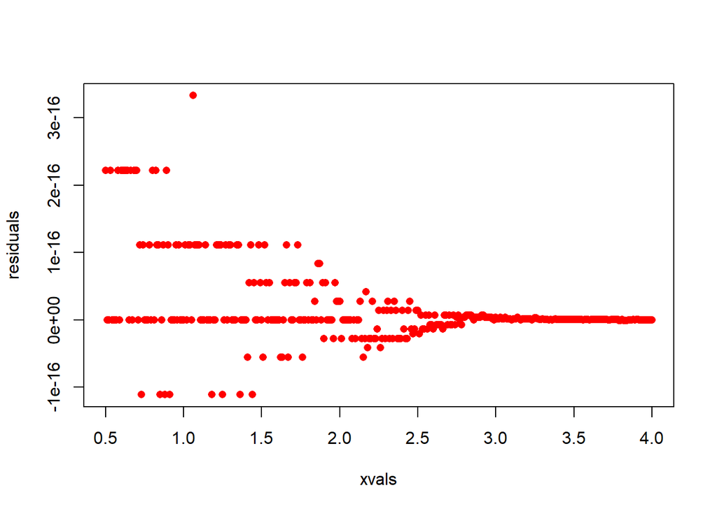

```r
residuals <- f_x - f_d
plot(xvals, residuals, col="red", pch=16)
```

The residual plot shows that the difference of the values is of the order $10^{-16}$ and the difference is larger for the first half of the data.

```r
bool <- (f_x == f_d)*1
n_true <- length(bool[bool==TRUE])
l_bool <- length(bool)
sprintf("The percent of values that agree exactly is %s %%", (n_true/l_bool)*100)
```

```
## [1] "The percent of values that agree exactly is 25.6410256410256 %"
```

We see that although there is very little difference between the data, only a quarter of the data match exactly (all numbers in the decimal are the same).

```r
sprintf("The truncated normal density: mean = %s, sd = %s", mean(f_x), sd(f_x))
```

```
## [1] "The truncated normal density: mean = 0.286498475251305, sd = 0.350049975987922"
```

```r
sprintf("Results of dtruncnorm(): mean = %s, sd = %s", mean(f_d), sd(f_d))
```

```
## [1] "Results of dtruncnorm(): mean = 0.286498475251305, sd = 0.350049975987922"
```

```r
sprintf("Difference between values: diff_mean = %s, diff_sd = %s", mean(f_x)-mean(f_d), sd(f_x)-sd(f_d))
```

```
## [1] "Difference between values: diff_mean = 5.55111512312578e-17, diff_sd = 0"
```

Finally, the mean and standard deviation are almost exact with the difference between the means being of the order $10^{-17}$.

All in all, I believe the values I computed for the truncated normal density and the ones from the package are similar enough that it does not matter which approximation is used in further calculations.

8. What is the problem/s with this sampling method? Exemplify with code.

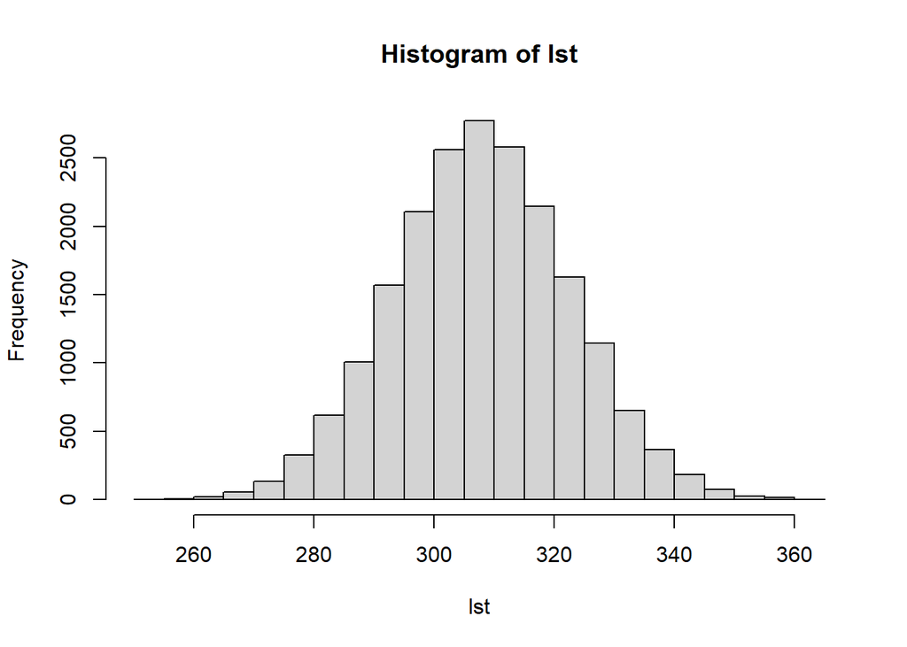

```r
lst <- c()
N = 20000
for(i in 1:N){
  ss <- rnorm(1000, mean=0, sd=1) # generate 10000 quasi-random numbers
  lst <- append(lst, length(ss[ss>=0.5])) # save length of truncated data
}

hist(lst)
```

We see that the quantity of quasi-random numbers that satisfy the truncation condition for 1000 data points generated by `rnorm()` is not truly random. Instead, the quantity can range from approximately 260 to 360. Lets see if we can increase the quantity of values in the truncated distribution by increasing the number of data points generated by `rnorm()`.

```r
N = 10000
tseq <- seq(1000, 20000, 2000)
means <- c()
sds <- c()
for(t in tseq){

  lst <- c()
  for(i in 1:N){
    ss <- rnorm(t, mean=0, sd=1) # generate 10000 quasi-random numbers
    lst <- append(lst, length(ss[ss>=0.5])) # save length of truncated data
  }

  means <- append(means, mean(lst))
  sds <- append(sds, sd(lst))

}
```

In this calculation, we iterate through the number of data points to generate via the sequence named `tseq`. For each of them, we compute the mean and standard deviation of the quantity of numbers that satisfy the truncation condition.

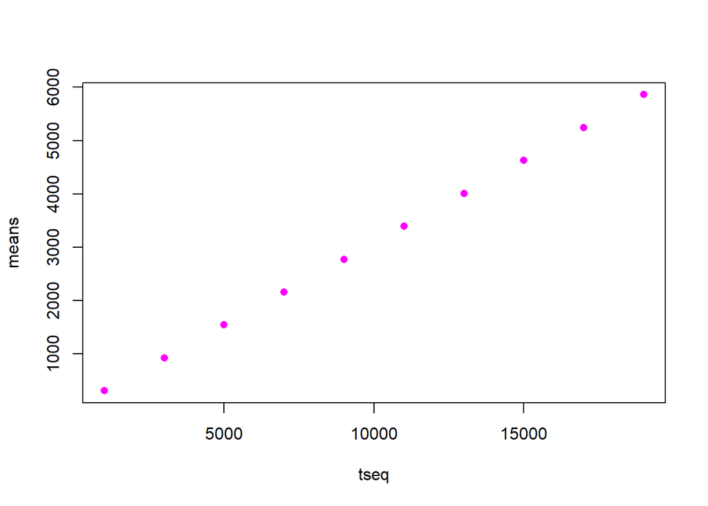

```r
plot(tseq, means, pch=16, col="magenta")
```

As we increase the number of data points generated by `rnorm()` we linearly get more points that satisfy our truncation condition. With this plot, we further exemplify how the length of the sample is quasi-random, it is normally distributed and thus has predictability. Yet the disadvantage still remains that the user cannot specify the quantity of data point for the truncated distribution with complete certainty.

EXTRA CREDIT:

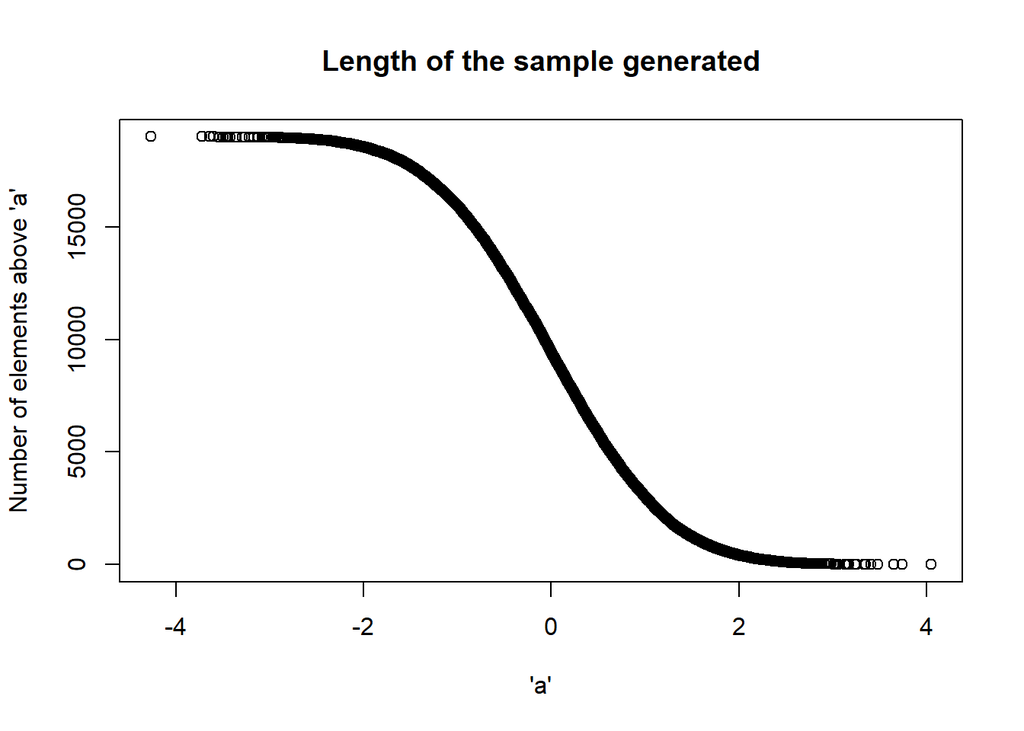

```r
set.seed(4) # keep the random numbers generated
n = 19000
s4 <- rnorm(n, mean=0, sd=1) # generate 10000 quasi-random numbers
ints <- (n-1):0
srt <- sort(s4)
plot(srt, ints, xlab="'a'", ylab="Number of elements above 'a'", main="Length of the sample generated")
```

```r
sprintf("The predicted length for n=19000 is %s", means[10])
```

```
## [1] "The predicted length for n=19000 is 5861.9246"
```

```r
sprintf("An example length for n=19000 is %s", length(s4[s4>=0.5]))
```

```
## [1] "An example length for n=19000 is 5845"
```

```r
sprintf("These values are similar and the example falls within the standard deviation of %s", sds[10])
```

```
## [1] "These values are similar and the example falls within the standard deviation of 63.6706251711962"
```

## Part II

### 1. Syntax and class-typing

1. For each of the following commands, either explain why they should be errors, or explain the non-erroneous result.

```r
vector1 <- c("5", "12", "7", "32") # the result is a vector of characters (not numbers)
# because the input is quoted

max(vector1) # The result is "7" because it has the largest character value compared to
```

```
## [1] "7"
```

```r
# other first characters of the elements (5, 1, and 3)

sort(vector1) # The elements are sorted from smallest to largest based on the first character
```

```
## [1] "12" "32" "5"  "7"
```

```r
# value of each element (1, 3, 5, 7)

#sum(vector1) # there is an error because sum() only takes numeric or complex or logical
# vectors but we input a vector of characters
```

2. For the next series of commands, either explain their results, or why they should produce errors

```r
vector2 <- c("5",7,12) # the result is a vector of characters because the vector must be
# of a single data type and we input a character for one of the elements

#vector2[2] + vector2[3] # there is an error because only numeric variables can be added
# with the binary operator '+'

list4 <- list(z1="6", z2=42, z3="49", z4=126) # the result is a list of 4 elements because
# lists can hold multiple data types aka z1 is a character whereas z2 is a number

list4[[2]] + list4[[4]] # the result is the number 168 because that is the sum of the numbers
```

```
## [1] 168
```

```r
# 42 and 126

#list4[2] + list4[4] # the result is an error because we cannot use the binary operator '+'
# to combine two lists of 1 element
```

### 2. Some regression

The following code generates a sequence of `X` values from 1 to 100, each three times. It defines `Y` as a linear function of `X` plus normal noise.

1. Carefully explain each of the computations: which functions are in it, in which order, what are their respective inputs ando utputs, how are the computations performed.

```r
n = 100 # assign 100 to the variable n

X = rep(1:n, each = 3) # We input an integer vector 1:n (sequence of values from 1 to 100)
# and the quantity of replications 3 into the function rep() which outputs an integer vector
# of length 300 = (length of sequence) x (number of replications). This computation is performed
# by replicating the first element 3 times, then the next element, then the next...

Y = 0.5 + 2 * X + rnorm(100 * 3) # We input the number of observations 100*3=300 into the rnorm()
# function and it outputs a vector of quantities with length = 300. Because rnorm(100*3) and X
# have the same length (numbers 0.5 and 2 will be recycled to have this length) we can perform
# operations / add them. Thus, the result is a vector of quantities with length = 300 named 'Y'.
```

2. The following code regresses `Y` on `X` and presents the estimated coefficients and predicted values (expected `Y` values for the same `X` values). i. What are the corresponding data types? ii. Do the results make sense to you (regression-wise)? Why?

```r
reg_Y_X = lm(Y ~ X) # 'Y ~ X' is interpreted as a specification that the response 'Y' is
# modelled by a linear predictor specified symbolically by 'X'. The output is a list of 12

coef(reg_Y_X) # We input the list object reg_Y_X into the function coef() which extracts the
```

```
## (Intercept)           X
##   0.5493468   1.9981886
```

```r
# linear model coefficients. The output is a named numerical vector which holds intercept, slope

predict(reg_Y_X) # The function predicts the results of the linear model. The output is a named
```

[output not shown]

[output cut: 31 more lines]

```
## 164.400814 166.399003 166.399003 166.399003 168.397192 168.397192 168.397192
##        253        254        255        256        257        258        259
## 170.395380 170.395380 170.395380 172.393569 172.393569 172.393569 174.391757
##        260        261        262        263        264        265        266
## 174.391757 174.391757 176.389946 176.389946 176.389946 178.388135 178.388135
##        267        268        269        270        271        272        273
## 178.388135 180.386323 180.386323 180.386323 182.384512 182.384512 182.384512
##        274        275        276        277        278        279        280
## 184.382701 184.382701 184.382701 186.380889 186.380889 186.380889 188.379078
##        281        282        283        284        285        286        287
## 188.379078 188.379078 190.377266 190.377266 190.377266 192.375455 192.375455
##        288        289        290        291        292        293        294
## 192.375455 194.373644 194.373644 194.373644 196.371832 196.371832 196.371832
##        295        296        297        298        299        300
## 198.370021 198.370021 198.370021 200.368210 200.368210 200.368210
```

```r
# numerical vector of length 300
```

The results make sense to me because the values of `Y` are that of a line with intercept = 0.5 and slope = 2 that has some random deviations. Thus, our result from `coef()` is a linear fit to `Y` with intercept close to 0.5 and approximately 2. It will not have these values exactly due to the random deviations in the data that we added via `rnorm()`.

3. The data type of `reg_Y_X` is a list, specifically a named list. That is, we can address `reg_Y_x[[1]]` according to its name, so `reg_Y_X$coefficients` is the same as `reg_Y_X[[1]]`.

What are the elements that comprise `reg_Y_X` and their respective data types? (there are 12 of those, 2 of them are types that we haven’t discussed yet) (please distinguish names types from those without names). You can use functions of the `is.____` family or other methods to prove your claims.

The elements that comprise `reg_Y_X`: - coefficients (double [2]) - residuals (double [300]) - effects (double [300]) - rank (integer [1]) - fitted.values (double [300]) - assign (integer [2]) - qr (list [5] (S3: qr)) - df.residual (integer [1]) - xlevels (list [0]) - call (language) - terms (formula) - model (list [300 x 2] (S3: data.frame))

```r
for(i in 1:12){
  print(i)
  print(is(reg_Y_X[[i]]))
}
```

```
## [1] 1
## [1] "numeric" "vector"
## [1] 2
## [1] "numeric" "vector"
## [1] 3
## [1] "numeric" "vector"
## [1] 4
## [1] "integer"             "double"              "numeric"
## [4] "vector"              "data.frameRowLabels"
## [1] 5
## [1] "numeric" "vector"
## [1] 6
## [1] "integer"             "double"              "numeric"
## [4] "vector"              "data.frameRowLabels"
## [1] 7
## [1] "qr"
## [1] 8
## [1] "integer"             "double"              "numeric"
## [4] "vector"              "data.frameRowLabels"
## [1] 9
## [1] "list"   "vector"
## [1] 10
## [1] "call"     "language"
## [1] 11
## [1] "terms"
## [1] 12
## [1] "data.frame" "list"       "oldClass"   "vector"
```

4. In light of the above, explain what the `coef` function from 3b does.

```r
print(reg_Y_X[[1]])
```

```
## (Intercept)           X
##   0.5493468   1.9981886
```

```r
print(coef(reg_Y_X))
```

```
## (Intercept)           X
##   0.5493468   1.9981886
```

The function `coef()` returns the named numerical vector which holds the slope and intercept coefficient values of the model.